# Background

MNIST ("Modified National Institute of Standards and Technology") is a dataset comprised of handwritten images of digits from zero through nine. The goal of this assignment is to correctly identify the digit of each image. Therefore, this is a multiclass classification problem.

The MNIST data set is comprised of 42,000 digits and 784 columns (there is an additional column for the digit classification). Each image is 28 pixels in height and 28 pixels in width, for a total of 784 pixels, which corresponds to the 784 columns. The data within each column represents the lightness or darkness of each pixel.

In this assignment, Python scikit-learn is used to build several different neural networks. While Tensor Flow was considered for this assignment, there were OSX runtime errors upon installation. A 2 x 2 design is used to build different models with run times and accuracy scores reported. Results are submitted to Kaggle for scoring. Commentary is provided at the end on which hyperparameter settings are most trustworthy.

# Data Initation

To begin, we read in the MNIST data. The data used for this assignment has already been split into training and test sets. The test set, however, does not have the final digit classification (response variable), as the predictions will be submitted to Kaggle for scoring.

```python
RANDOM_SEED = 42

# import packages
import pandas as pd
import numpy as np
import matplotlib.pyplot as plt
import seaborn as sns

# for model building and results
from sklearn.metrics import accuracy_score, confusion_matrix, classification_report, roc_auc_score
from math import sqrt
from sklearn.model_selection import cross_validate, cross_val_score, cross_val_predict, train_test_split
from sklearn.preprocessing import StandardScaler
from sklearn.decomposition import PCA
from sklearn.model_selection import GridSearchCV
from sklearn.neural_network import MLPClassifier

# for display
from prettytable import PrettyTable

# misc
import time

# color palette
current_palette = sns.color_palette() #10 colors
```

```python
# read in the data
mnist_train = pd.read_csv('mnist_train.csv')
mnist_test = pd.read_csv('mnist_test.csv')
```

```python
# inspect the data
print("mnist_train shape: ", mnist_train.shape)
print("mnist_test shape: ", mnist_test.shape)
mnist_train.info()
mnist_train.columns
```

```
mnist_train shape:  (42000, 785)
mnist_test shape:  (28000, 784)
<class 'pandas.core.frame.DataFrame'>
RangeIndex: 42000 entries, 0 to 41999
Columns: 785 entries, label to pixel783
dtypes: int64(785)
memory usage: 251.5 MB
```

```
Index(['label', 'pixel0', 'pixel1', 'pixel2', 'pixel3', 'pixel4', 'pixel5',
       'pixel6', 'pixel7', 'pixel8',
       ...
       'pixel774', 'pixel775', 'pixel776', 'pixel777', 'pixel778', 'pixel779',
       'pixel780', 'pixel781', 'pixel782', 'pixel783'],
      dtype='object', length=785)
```

We can see that the training data is comprised of 42,000 rows with 785 columns, 784 of which are representative of pixel lightness or darkness. We can also see that the test data set only has 784 columns.

# Data Preparation

To prepare the data for modeling, we first standardize the data. This step is extremely important for neural networks, as it ensures that no extra bias is introduced into the model building process and it helps speed up processing time. Moreover, by standardizing the data, we can also take advantage of regularization techniques and ensure we get stable results.

```python
# need to define X & y for model-building
X_train, y_train = mnist_train.loc[:, ~mnist_train.columns.isin(['label'])], mnist_train['label']
```

```python
import warnings
from sklearn.exceptions import DataConversionWarning
warnings.simplefilter(action='ignore', category=DataConversionWarning)

# scale data before building models
scale_start_time = time.time()

scaler = StandardScaler()
scaler.fit(X_train)
X_scaled = scaler.transform(X_train)
test_scaled = scaler.transform(mnist_test) # scale the test set using scaler from training

scale_elapsed_time = time.time() - scale_start_time

print('Run time for scaling was: ', scale_elapsed_time, 'seconds')
```

```
Run time for scaling was:  3.0775270462036133 seconds
```

```python
# also generate PCs to test performance
pca_start_time = time.time()

pca = PCA(n_components=.95, random_state = RANDOM_SEED)
pca.fit(X_scaled)
X_reduced = pca.transform(X_scaled)
X_test_pca = pca.transform(test_scaled)
pca_elapsed_time = time.time() - pca_start_time

print('Run time for generating PCs was: ', pca_elapsed_time, 'seconds')
print('The number of PCs generated were: ', pca.n_components_)
```

```
Run time for generating PCs was:  12.1196448802948 seconds
The number of PCs generated were:  320
```

In utilizing PCA techniques, it also important to standardize the data beforehand. Since PCA is a variable reduction technique, it transforms variables in an attempt to maximize variance. If standardization were not done, then variables with a higher variance would skew the PCA rotation/transformation process.

From the PCA output, we can see that by retaining 95% of data variance, we are able to reduce the number of variables from 784 to 320.

# Model Building

In this assignment, a 2 x 2 factorial design is considered to test some different neural network hyperparameters. The parameters considered in this assignment are shown in the table below. It is worth noting that once the best model is selected from the parameters below, results will then be compared using principal components.

One additional callout: cross validation with a parameter grid was considered for hyperparameter tuning. However, the processing time to generate models was too great so this approach had to be abandoned. If more time allowed, this approach would be used to build the optimal model.

```python
a = PrettyTable()
a.field_names = ["Model Name","Number of Layers","Nodes per Layer"]
a.add_row(["Model One",1,20])
a.add_row(["Model Two",1,200])
a.add_row(["Model Three",2,20])
a.add_row(["Model Four",2,200])
print(a.get_string(title="Neural Network Experimental Factors"))
```

```
+--------------------------------------------------+
|       Neural Network Experimental Factors        |
+-------------+------------------+-----------------+
|  Model Name | Number of Layers | Nodes per Layer |
+-------------+------------------+-----------------+
|  Model One  |        1         |        20       |
|  Model Two  |        1         |       200       |
| Model Three |        2         |        20       |
|  Model Four |        2         |       200       |
+-------------+------------------+-----------------+
```

In addition, a few functions are defined to help with analyzing goodness of fit statistics and in formatting the predictions for Kaggle submission. While functions could be defined to build the models, functions are not used to enable more control of the parameters within each model.

```python
def gof_metrics(pred):
    print("Precision, Recall, and F1 Score")
    print(classification_report(y_train, pred))
    print("_____________________________________________________")
    print("Accuracy")
    print(accuracy_score(y_train, pred))
```

```python
def confusion_matrix_heatmap(pred):
    cm = confusion_matrix(y_train, pred)
    cm = cm / cm.astype(np.float).sum(axis=1) #need to standardize the data first
    sns.heatmap(cm, vmin=0, vmax=1, cmap="Blues")
    plt.show()
```

```python
# make sure predictions are in right format
def pred_format(pred):
    pred = pd.DataFrame(pred, columns = ["Label"])
    pred['ImageId'] = range(1, len(pred) + 1)
    cols = pred.columns.tolist()
    cols = cols[-1:] + cols[:-1]
    pred_clean = pred[cols]
    return(pred_clean)
```

## Model One

Model one features one hidden layer with 20 nodes. A learning rate of .001 is used to build the model. A larger number of iterations, 500, is used to build the model to help with convergence. Early stopping is used to ensure that the model does not overfit the training set. Goodness of fit statistics are then shown to analyze model performance.

```python
m1_start_time = time.time()

# fit the model using best params
mlp_m1 = MLPClassifier(hidden_layer_sizes=(20),
                       learning_rate_init = .001,
                       max_iter = 500,
                       early_stopping = True,
                       random_state = RANDOM_SEED)
mlp_m1.fit(X_scaled, y_train)

# generate predictions
m1_pred = mlp_m1.predict(X_scaled)

m1_elapsed_time = time.time() - m1_start_time
```

```python
# share gof metrics
gof_metrics(m1_pred)
```

```
Precision, Recall, and F1 Score
              precision    recall  f1-score   support

           0       0.98      0.98      0.98      4132
           1       0.98      0.99      0.98      4684
           2       0.98      0.97      0.98      4177
           3       0.97      0.96      0.97      4351
           4       0.97      0.97      0.97      4072
           5       0.97      0.97      0.97      3795
           6       0.98      0.99      0.98      4137
           7       0.98      0.98      0.98      4401
           8       0.96      0.97      0.97      4063
           9       0.96      0.96      0.96      4188

   micro avg       0.97      0.97      0.97     42000
   macro avg       0.97      0.97      0.97     42000
weighted avg       0.97      0.97      0.97     42000

_____________________________________________________
Accuracy
0.9733095238095238
```

From the goodness of fit statistics above, we can see that this model fits the training data set fairly well overall, as it has an accuracy of 97.3%. The precision and recall values are also fairly consistent across each digit class, which is another good sign. There are not precision or recall values of 1, which means that the model is not extremely overfitting the training set. That being said, the precision and recall values for eights and nines are lower compared to other classes.

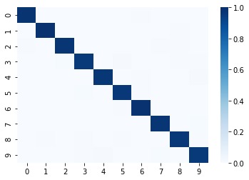

```python
# generate confusion matrix
confusion_matrix_heatmap(m1_pred)
```

From the confusion matrix, we can see that all classes seem to have similar performance, with few misclassifications.

We are now ready to generate predictions on the test set and submit the scores for review. Until we understand the test set scores, it is hard to know how well this model performs and if additional time should be spent on tuning other parameters.

```python
# generate test set predictions
m1pred_start_time = time.time()
m1_predictions = mlp_m1.predict(test_scaled)
m1pred_elapsed_time = time.time() - m1pred_start_time
```

```python
# make sure predictions are in right format
m1_predictions = pred_format(m1_predictions)
```

```python
# export results
m1_predictions.to_csv("assignment6_mnist_predictions_m1.csv", index=False)
```

```python
# total time
m1pred_elapsed_time + m1_elapsed_time
```

```
11.912174224853516
```

## Model Two

Model two features one hidden layer with 200 nodes. A relatively large alpha parameter is used for this model to help protect against overfitting. Using the default alpha parameter yielded precision and recall values of 1 for most/all digits and an accuracy score of over 99%, which is why the alpha parameter was invoked.

```python
m2_start_time = time.time()

# fit the model using best params
mlp_m2 = MLPClassifier(hidden_layer_sizes=(200),
                       learning_rate_init = .001,
                       max_iter = 500,
                       alpha = 1,
                       early_stopping = True,
                       random_state = RANDOM_SEED)
mlp_m2.fit(X_scaled, y_train)

# generate predictions
m2_pred = mlp_m2.predict(X_scaled)

m2_elapsed_time = time.time() - m2_start_time
```

```python
# share gof metrics
gof_metrics(m2_pred)
```

```
Precision, Recall, and F1 Score
              precision    recall  f1-score   support

           0       0.99      0.99      0.99      4132
           1       0.98      0.99      0.98      4684
           2       0.98      0.98      0.98      4177
           3       0.98      0.96      0.97      4351
           4       0.98      0.98      0.98      4072
           5       0.97      0.98      0.98      3795
           6       0.99      0.98      0.99      4137
           7       0.98      0.97      0.98      4401
           8       0.97      0.97      0.97      4063
           9       0.97      0.97      0.97      4188

   micro avg       0.98      0.98      0.98     42000
   macro avg       0.98      0.98      0.98     42000
weighted avg       0.98      0.98      0.98     42000

_____________________________________________________
Accuracy
0.9788095238095238
```

The confusion matrix below shows similar results in that the model has very few predictions not on the diagonal.

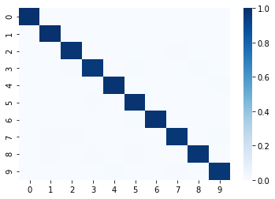

```python
# generate confusion matrix
confusion_matrix_heatmap(m2_pred)
```

```python
# generate test set predictions
m2pred_start_time = time.time()
m2_predictions = mlp_m2.predict(test_scaled)
m2pred_elapsed_time = time.time() - m2pred_start_time
```

```python
# make sure predictions are in right format
m2_predictions = pred_format(m2_predictions)
```

```python
# export results
m2_predictions.to_csv("assignment6_mnist_predictions_m2.csv", index=False)
```

```python
# total time
m2pred_elapsed_time + m2_elapsed_time
```

```
68.50646877288818
```

We can see here that the elapsed time to generate this model was greater than above, as more nodes were considered. This result is something to keep in mind for the future.

## Model Three

Model three features two hidden layers with 20 nodes each.

```python
m3_start_time = time.time()

# fit the model using best params
mlp_m3 = MLPClassifier(hidden_layer_sizes=(20,20),
                       learning_rate_init = .001,
                       max_iter = 500,
                       early_stopping = True,
                       random_state = RANDOM_SEED)
mlp_m3.fit(X_scaled, y_train)

# generate predictions
m3_pred = mlp_m3.predict(X_scaled)

m3_elapsed_time = time.time() - m3_start_time
```

```python
# share gof metrics
gof_metrics(m3_pred)
```

```
Precision, Recall, and F1 Score
              precision    recall  f1-score   support

           0       0.99      0.99      0.99      4132
           1       0.99      0.99      0.99      4684
           2       0.98      0.98      0.98      4177
           3       0.98      0.97      0.98      4351
           4       0.98      0.99      0.99      4072
           5       0.98      0.98      0.98      3795
           6       0.99      0.99      0.99      4137
           7       0.97      0.99      0.98      4401
           8       0.97      0.98      0.97      4063
           9       0.98      0.97      0.98      4188

   micro avg       0.98      0.98      0.98     42000
   macro avg       0.98      0.98      0.98     42000
weighted avg       0.98      0.98      0.98     42000

_____________________________________________________
Accuracy
0.9820952380952381
```

We can see that this model has an even higher accuracy and precision and recall scores than the two models above. It seems like adding another hidden layer helps to improve model fit. Once again, it is hard to know if other parameters should be invoked without better understanding the difference between training and test set performance.

The confusion matrix shows similar results to above. The model seems to do a good job predicting values for each class.

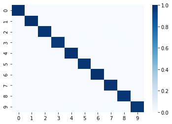

```python
# generate confusion matrix
confusion_matrix_heatmap(m3_pred)
```

```python
# generate test set predictions
m3pred_start_time = time.time()
m3_predictions = mlp_m3.predict(test_scaled)
m3pred_elapsed_time = time.time() - m3pred_start_time
```

```python
# make sure predictions are in right format
m3_predictions = pred_format(m3_predictions)
```

```python
# export results
m3_predictions.to_csv("assignment6_mnist_predictions_m3.csv", index=False)
```

```python
# total time
m3pred_elapsed_time + m3_elapsed_time
```

```
19.414432048797607
```

## Model Four

Model four features two hidden layers with 200 nodes each. Like model two, the alpha parameter is set to a higher value to protect against overfitting.

```python
m4_start_time = time.time()

# fit the model using best params
mlp_m4 = MLPClassifier(hidden_layer_sizes=(200,200),
                       learning_rate_init = .001,
                       max_iter = 500,
                       alpha = 1,
                       early_stopping = True,
                       random_state = RANDOM_SEED)
mlp_m4.fit(X_scaled, y_train)

# generate predictions
m4_pred = mlp_m4.predict(X_scaled)

m4_elapsed_time = time.time() - m4_start_time
```

```python
# share gof metrics
gof_metrics(m4_pred)
```

```
Precision, Recall, and F1 Score
              precision    recall  f1-score   support

           0       0.99      0.99      0.99      4132
           1       0.98      1.00      0.99      4684
           2       0.99      0.98      0.98      4177
           3       0.98      0.98      0.98      4351
           4       0.99      0.96      0.98      4072
           5       0.97      0.99      0.98      3795
           6       0.98      0.99      0.98      4137
           7       0.99      0.98      0.99      4401
           8       0.99      0.97      0.98      4063
           9       0.97      0.98      0.97      4188

   micro avg       0.98      0.98      0.98     42000
   macro avg       0.98      0.98      0.98     42000
weighted avg       0.98      0.98      0.98     42000

_____________________________________________________
Accuracy
0.9813095238095239
```

The confusion matrix below shows consistent predictions across every class.

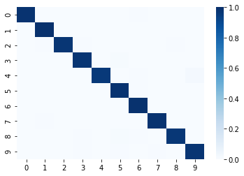

```python
# generate confusion matrix
confusion_matrix_heatmap(m4_pred)
```

```python
# generate test set predictions
m4pred_start_time = time.time()
m4_predictions = mlp_m4.predict(test_scaled)
m4pred_elapsed_time = time.time() - m4pred_start_time
```

```python
# make sure predictions are in right format
m4_predictions = pred_format(m4_predictions)
```

```python
# export results
m4_predictions.to_csv("assignment6_mnist_predictions_m4.csv", index=False)
```

```python
# total time
m4pred_elapsed_time + m4_elapsed_time
```

```
102.65730929374695
```

# Model Evaluation

Now it is time to pull everything together. To start, below is a table that captures the performance of all four models above. All test scores were received by Kaggle. Submissions were under the username of juliarodd.

```python
a = PrettyTable()
a.field_names = ["Model Name","Number of Layers","Nodes per Layer", "Processing Time", "Training Set Accuracy", "Test Set Accuracy"]
a.add_row(["Model One",1,20,round(m1_elapsed_time,1),round(accuracy_score(y_train, m1_pred),3),0.91814])
a.add_row(["Model Two",1,200,round(m2_elapsed_time,1),round(accuracy_score(y_train, m2_pred),3),0.96414])
a.add_row(["Model Three",2,20,round(m3_elapsed_time,1),round(accuracy_score(y_train, m3_pred),3),0.94828])
a.add_row(["Model Four",2,200,round(m4_elapsed_time,1),round(accuracy_score(y_train, m4_pred),3),0.96300])
print(a.get_string(title="Neural Network Results"))
```

[output not shown]

We can see that model two performed the best, followed by model four. Both of these models had a larger number of nodes at 200 compared to the other models. Therefore, it seems that for more complex problem, a larger number of nodes has a significant impact on overall performance.

## PCA Model

While the models above were built using all variables in the MNIST data frame, another option is to utilize PCA techniques, which generates fewer variables, to build a model.

It is hypothesized that the PCA model will not perform as well as the model with all variables, but it will have faster performance.

The same paramaters as model four is used for comparative purposes here, as using one hidden layer did not seem to be an interesting experiment.

```python
m5_start_time = time.time()

# fit the model using best params
mlp_m5 = MLPClassifier(hidden_layer_sizes=(200,200),
                       learning_rate_init = .001,
                       max_iter = 500,
                       alpha = 1,
                       early_stopping = True,
                       random_state = RANDOM_SEED)
mlp_m5.fit(X_reduced, y_train)

# generate predictions
m5_pred = mlp_m5.predict(X_reduced)

m5_elapsed_time = time.time() - m5_start_time
```

```python
# share gof metrics
gof_metrics(m5_pred)
```

```
Precision, Recall, and F1 Score
              precision    recall  f1-score   support

           0       0.99      0.99      0.99      4132
           1       0.99      0.99      0.99      4684
           2       0.98      0.98      0.98      4177
           3       0.99      0.97      0.98      4351
           4       0.98      0.99      0.98      4072
           5       0.99      0.97      0.98      3795
           6       0.99      0.99      0.99      4137
           7       0.98      0.98      0.98      4401
           8       0.98      0.98      0.98      4063
           9       0.97      0.98      0.97      4188

   micro avg       0.98      0.98      0.98     42000
   macro avg       0.98      0.98      0.98     42000
weighted avg       0.98      0.98      0.98     42000

_____________________________________________________
Accuracy
0.9828095238095238
```

```python
# generate test set predictions
m5pred_start_time = time.time()
m5_predictions = mlp_m5.predict(X_test_pca)
m5pred_elapsed_time = time.time() - m5pred_start_time
```

```python
# make sure predictions are in right format
m5_predictions = pred_format(m5_predictions)
```

```python
# export results
m5_predictions.to_csv("assignment6_mnist_predictions_m5.csv", index=False)
```

```python
# total time
m5pred_elapsed_time + m5_elapsed_time
```

```
55.91732859611511
```

The predictions for this model were submitted to Kaggle for scoring under the username of juliarodd. The accuracy score was: 0.96885, which is an improvement over all the models above. Therefore, it seems like PCA could be used as a technique to protect against overfitting when the model parameters are more complex. Additionally, we can see here that the performance was about two times as fast as the same model (model four) that did not utilize PCA techniques.

# Summary and Conclusions

From the results above, models with one versus two hidden layers were compared to one another in addition to scaling the number of nodes from a small (20) to large (200) value. While the model with one layer and 200 nodes was the best-performing model, the model with two layers and 200 nodes was close behind it.

Depending on the complexity of the business problem/data set, the results above help to show that:

- A large number of nodes helps to increase model performance.
- Invoking the alpha parameter and early stopping are good measures to consider to help protect against overfitting.
- Alternatively, PCA could be used to protect against overfitting. This method has the advantage of faster processing time.
- More time/experimentation is needed to determine the optimal number of hidden layers.
- Models with more hidden layers have comparable performance to models with one hidden layer. In other words, neural networks scale fairly well.
- In general, neural networks are a powerful modeling method but ample time is needed to build an optimal model that does not overfit the data.

# Appendix

## Bonus: Model with more nodes

Results were submitted to Kaggle and yielded a test set accuracy score of: 0.96085.

This model featured five hidden layers, each with 200 nodes. It was hypothesized that test set performance would increase by using more nodes, but this did not prove to be true.

```python
m6_start_time = time.time()

# fit the model using best params
mlp_m6 = MLPClassifier(hidden_layer_sizes=(200,200,200,200,200),
                       learning_rate_init = .001,
                       max_iter = 500,
                       alpha = 2,
                       early_stopping = True,
                       random_state = RANDOM_SEED)
mlp_m6.fit(X_scaled, y_train)

# generate predictions
m6_pred = mlp_m6.predict(X_scaled)

m6_elapsed_time = time.time() - m6_start_time
```

```python
# share gof metrics
gof_metrics(m6_pred)
```

```
Precision, Recall, and F1 Score
              precision    recall  f1-score   support

           0       0.97      0.99      0.98      4132
           1       0.98      0.99      0.98      4684
           2       0.97      0.98      0.97      4177
           3       0.97      0.97      0.97      4351
           4       0.98      0.98      0.98      4072
           5       0.97      0.98      0.97      3795
           6       0.98      0.99      0.99      4137
           7       0.98      0.97      0.97      4401
           8       0.97      0.97      0.97      4063
           9       0.99      0.94      0.96      4188

   micro avg       0.98      0.98      0.98     42000
   macro avg       0.98      0.98      0.98     42000
weighted avg       0.98      0.98      0.98     42000

_____________________________________________________
Accuracy
0.9758333333333333
```

```python
# generate test set predictions
m6pred_start_time = time.time()
m6_predictions = mlp_m6.predict(test_scaled)
m6pred_elapsed_time = time.time() - m6pred_start_time
```

```python
# make sure predictions are in right format
m6_predictions = pred_format(m6_predictions)
```

```python
# export results
m6_predictions.to_csv("assignment6_mnist_predictions_m6.csv", index=False)
```

```python
# total time
m6pred_elapsed_time + m6_elapsed_time
```

```
152.11424803733826
```

## Bonus: Model with more nodes and PCA

The results of the below model were submitted to Kaggle for scoring and received an accuracy score of: 0.96328. Thus, we can see that as we add more layers, models that have utilized PCA are performing better.

```python
m7_start_time = time.time()

# fit the model using best params
mlp_m7 = MLPClassifier(hidden_layer_sizes=(200,200,200,200,200),
                       learning_rate_init = .001,
                       max_iter = 500,
                       alpha = 2,
                       early_stopping = True,
                       random_state = RANDOM_SEED)
mlp_m7.fit(X_reduced, y_train)

# generate predictions
m7_pred = mlp_m7.predict(X_reduced)

m7_elapsed_time = time.time() - m7_start_time
```

```python
# share gof metrics
gof_metrics(m7_pred)
```

```
Precision, Recall, and F1 Score
              precision    recall  f1-score   support

           0       0.98      0.99      0.99      4132
           1       0.98      0.99      0.99      4684
           2       0.98      0.98      0.98      4177
           3       0.98      0.98      0.98      4351
           4       0.99      0.97      0.98      4072
           5       0.98      0.98      0.98      3795
           6       0.98      0.99      0.99      4137
           7       0.98      0.98      0.98      4401
           8       0.98      0.97      0.97      4063
           9       0.96      0.98      0.97      4188

   micro avg       0.98      0.98      0.98     42000
   macro avg       0.98      0.98      0.98     42000
weighted avg       0.98      0.98      0.98     42000

_____________________________________________________
Accuracy
0.9801666666666666
```

```python
# generate test set predictions
m7pred_start_time = time.time()
m7_predictions = mlp_m7.predict(X_test_pca)
m7pred_elapsed_time = time.time() - m7pred_start_time
```

```python
# make sure predictions are in right format
m7_predictions = pred_format(m7_predictions)
```

```python
# export results
m7_predictions.to_csv("assignment6_mnist_predictions_m7.csv", index=False)
```

```python
# total time
m7pred_elapsed_time + m7_elapsed_time
```

```
193.48318719863892
```